# Classification with Logistic Regression

Application: Predicting Disease (Framingham Study)

Simon Lee, Jack Taiclet, Eric Li

5/07/2024

# 1. Overview

The goal of this analysis is to develop a classification model with logistic regression to predict the 10-year risk of coronary heart disease (CHD). We will use data from the Framingham Study, an observational study of residents in Framingham, Massachusetts that began in 1948 to assess risk factors for cardiovascular disease. The study subsequently recruited 2 more generations of participants. https://framinghamheartstudy.org/

# 2. Data Summary

Let’s examine the Framingham dataset, which contains the following variables for 3,658 participants:

**Outcome**

- **TenYearCHD:** Binary variable if coronary heart disease (CHD) diagnosed within 10 years (1=yes, 0=no)

**Demographics**

- **Male:** Binary variable for biological sex of patient (1=male, 0=female)
- **Age:** Age in years at first examination
- **Education:** Categorical variable for education (1=some high school, 2=high school grad, 3=some college, 4=college grad)

**Smoking**

- **Smoker:** Binary variable for current smoker (1=yes, 0=no)
- **CigsPerDay:** Number of cigarettes smoked per day

**Medical history**

- **BPMeds:** Binary variable for blood pressure medication (1=yes, 0=no)
- **Stroke:** Binary variable for prior stroke (1=yes, 0=no)
- **Hyper:** Binary variable for current hypertension (1=yes, 0=no)
- **Diabetes:** Binary variable for current diabetes (1=yes, 0=no)

**Labs**

- **TotChol:** Total cholesterol (mg/dL)
- **SysBP:** Systolic blood pressure
- **DiaBP:** Diastolic blood pressure
- **BMI:** Body mass index (weight/height^2)
- **HeartRate:** Heart rate (beats per minute)
- **Glucose:** Blood glucose level (mg/dL)

Let’s first load some useful libraries.

```r
library(sjPlot)
library(caTools)
library(ROCR)
library(tidyverse)
library(jtools)
library(scales)
library(RColorBrewer)
library(wesanderson)
```

Use read.csv() to load the dataset. Convert Education to a factor variable, rename the TenYearCHD variable as CHD, rename the Male variable as Sex, and convert Sex to factor variable with text labels.

```r
setwd("/Users/simonlee/UCLA-Grad-Courses/MGMT298/p3")
FRAMINGHAM = read.csv("framingham.csv")
FRAMINGHAM$Education = as.factor(FRAMINGHAM$Education)
FRAMINGHAM = rename(FRAMINGHAM, CHD = TenYearCHD)
FRAMINGHAM = rename(FRAMINGHAM, Sex = Male)
FRAMINGHAM$Sex = ifelse(FRAMINGHAM$Sex == 1, "Male", "Female")
```

**QUESTION 1:** What fraction of patients experienced CHD?

```r
chd_fraction <- mean(FRAMINGHAM$CHD)
chd_fraction
```

```
## [1] 0.152269
```

From the table above it is 15.22% of patients experienced CHD.

# 3. Training the Model

Let’s first set the same seed. Then split the dataset into training and test datasets, with 75% as training.

```r
set.seed(46)
split = sample.split(FRAMINGHAM$CHD, SplitRatio = 0.75)
TRAIN = subset(FRAMINGHAM, split == TRUE)
TEST = subset(FRAMINGHAM, split == FALSE)
```

**QUESTION 2:** Run a logistic regression on the training dataset, using TenYearCHD as the dependent variable and all others as independent variables. Examine the odds ratios and confidence intervals. Which variables increase the risk of CHD and are statistically significant at 5%?

```r
LogitCHD <- glm(CHD ~ ., data = TRAIN, family = "binomial")
summ(LogitCHD, digits=3, exp=TRUE)
```

```
## MODEL INFO:
## Observations: 2744
## Dependent Variable: CHD
## Type: Generalized linear model
##   Family: binomial
##   Link function: logit
##
## MODEL FIT:
## χ²(17) = 270.598, p = 0.000
## Pseudo-R² (Cragg-Uhler) = 0.164
## Pseudo-R² (McFadden) = 0.116
## AIC = 2107.316, BIC = 2213.825
##
## Standard errors: MLE
## ---------------------------------------------------------------
##                     exp(Est.)    2.5%   97.5%    z val.       p
## ----------------- ----------- ------- ------- --------- -------
## (Intercept)             0.000   0.000   0.001   -10.795   0.000
## SexMale                 1.684   1.311   2.162     4.080   0.000
## Age                     1.065   1.049   1.082     8.026   0.000
## Education2              0.774   0.583   1.027    -1.775   0.076
## Education3              0.881   0.632   1.229    -0.745   0.456
## Education4              0.961   0.669   1.380    -0.216   0.829
## Smoker                  1.046   0.735   1.489     0.250   0.802
## CigsPerDay              1.019   1.004   1.033     2.534   0.011
## BPMeds                  1.205   0.704   2.065     0.680   0.497
## Stroke                  2.390   0.759   7.522     1.489   0.137
## Hyper                   1.153   0.844   1.573     0.894   0.371
## Diabetes                1.039   0.528   2.044     0.111   0.912
## TotChol                 1.003   1.001   1.006     2.399   0.016
## SysBP                   1.010   1.001   1.019     2.258   0.024
## DiaBP                   1.007   0.993   1.022     0.967   0.334
## BMI                     1.008   0.979   1.037     0.519   0.604
## HeartRate               0.999   0.989   1.008    -0.301   0.764
## Glucose                 1.007   1.003   1.012     3.025   0.002
## ---------------------------------------------------------------
```

The analysis of the logistic regression model reveals several variables that significantly increase the risk of coronary heart disease (CHD) at the 5% significance level. Being male increases the risk of CHD by 68.4%, as indicated by an odds ratio of 1.684 with a statistically significant p-value. Age also significantly increases the risk, with each additional year raising the risk by 6.5%. Cigarette consumption is another significant risk factor, with each additional cigarette smoked per day increasing CHD risk by 1.9%. Elevated total cholesterol and systolic blood pressure are also significant, increasing the risk by 0.3% and 1.0% per unit increase, respectively. Lastly, higher glucose levels are associated with a 0.7% increase in risk per unit increase, significantly impacting CHD risk.

To better visualize this, we can plot the odds ratios and 95% confidence intervals for each variable.

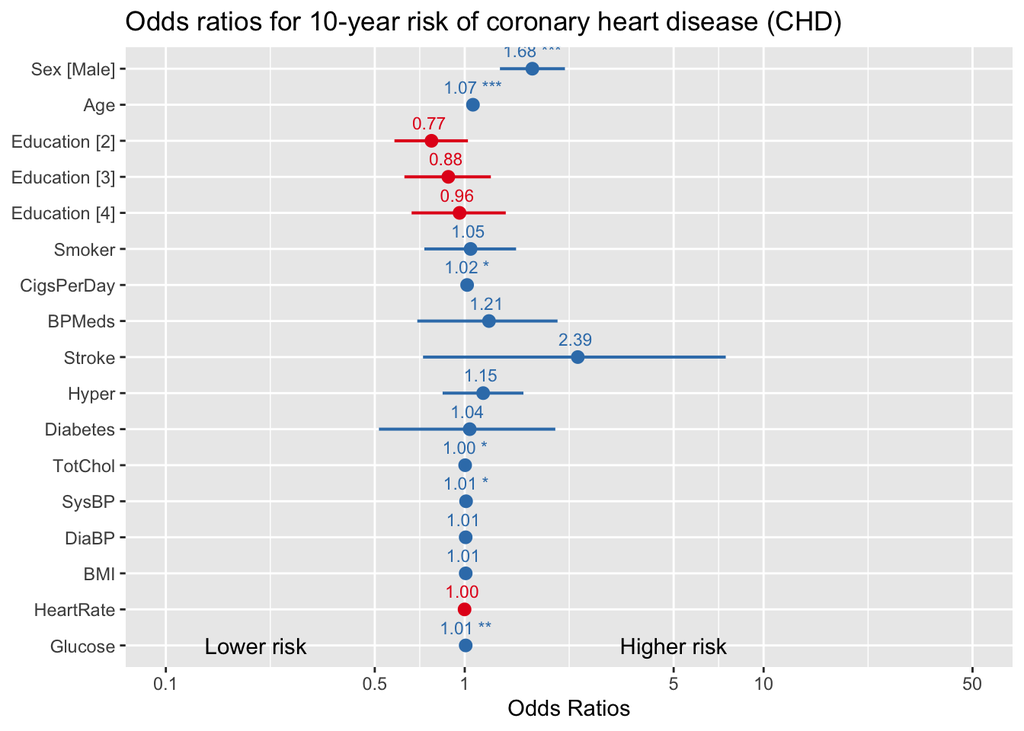

```r
plot_model(LogitCHD, show.values = TRUE, value.size=3, value.offset=0.5) +
  annotate("text", x = 1, y = 5, label = "Higher risk") +
  annotate("text", x = 1, y = 0.2, label = "Lower risk") +
  ggtitle("Odds ratios for 10-year risk of coronary heart disease (CHD)")
```

# 4. Testing the Model

**QUESTION 3:** Using the test dataset, predict the probability of 10-year CHD. Store this value in the TEST dataframe as a new column called PredictCHD.

```r
TEST$PredictCHD = predict(LogitCHD, newdata = TEST, type = "response")
```

**QUESTION 4:** Plot the predicted probability of CHD (y-axis) versus age (x-axis). Adjust the color by the CHD variable and adjust the size by SysBP. Manually add a horizontal line corresponding to a threshold of 0.6. Based on a visual inspection, do you think this threshold is too high or too low?

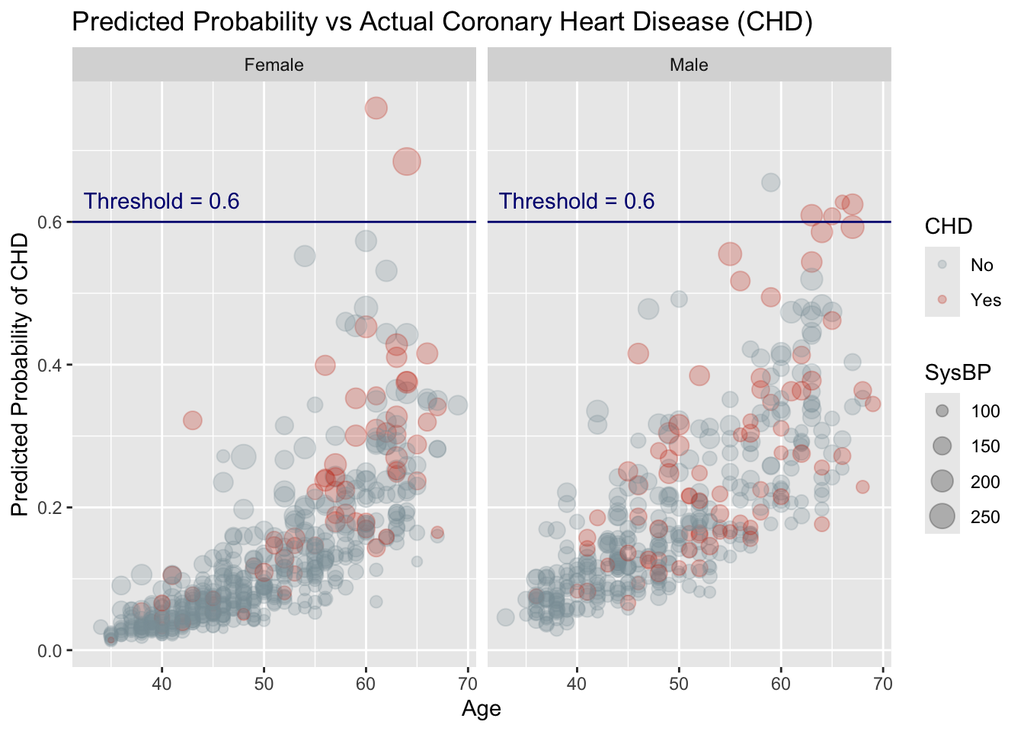

```r
TEST$CHD = as.factor(TEST$CHD)

ggplot(TEST, aes(x=Age, y=PredictCHD, color=CHD, size=SysBP)) +
  facet_wrap(~ Sex) +
  geom_point(alpha=0.25) +
  geom_hline(yintercept=0.6, color = "navy") +
  annotate(geom="text", x=40, y=0.63, label="Threshold = 0.6", color="navy") +
  scale_y_continuous("Predicted Probability of CHD") +
  scale_color_manual("CHD", labels = c("No", "Yes"), values = wes_palette("Royal1", n = )) +
  ggtitle("Predicted Probability vs Actual Coronary Heart Disease (CHD)")
```

Yes the threshold is way too high. Most of the datapoints lie under the threshold. It can be maybe lowered to 0.5 to capture more of the patients.

# 5. Model Accuracy

**QUESTION 5:** In the training data, which outcome for TenYearCHD is most likely? Suppose we use this outcome as our prediction for ALL patients in the test data. What is the accuracy of this base model? Hint: use the table() function to see raw observation counts.

```r
outcome_counts <- table(TRAIN$CHD)

# Find the most common outcome
most_common_outcome <- ifelse(outcome_counts[1] > outcome_counts[2], 0, 1)

# Assume this outcome for all test cases
constant_prediction <- rep(most_common_outcome, nrow(TEST))

# Calculate the accuracy of this base model
BaseAccuracy <- mean(constant_prediction == TEST$CHD)
BaseAccuracy
```

```
## [1] 0.8479212
```

The accuracy of the base model is 84.79%.

**QUESTION 6:** Generate a confusion matrix, assuming a probability cutoff threshold of 0.6. What is the accuracy of the model using the test dataset?

```r
Threshold = 0.6

Confusion = table(TEST$CHD, TEST$PredictCHD > Threshold)
Confusion
```

```
##
##     FALSE TRUE
##   0   774    1
##   1   133    6
```

```r
Accuracy = sum(diag(Confusion)) / nrow(TEST)
Accuracy
```

```
## [1] 0.8533917
```

**QUESTION 7:** Plot a receiver operating characteristic (ROC) curve and report the area-under-the-curve (AUC).

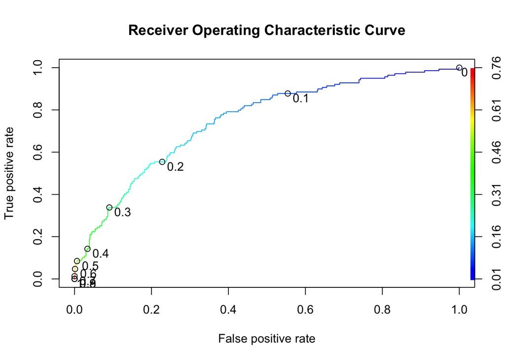

```r
ROCpred = prediction(TEST$PredictCHD, TEST$CHD)
ROCperf = performance(ROCpred, "tpr", "fpr")

plot(ROCperf, main = "Receiver Operating Characteristic Curve",
     colorize=TRUE, print.cutoffs.at=seq(0,1,by=0.1), text.adj=c(-0.3,1.0))
```

```r
AUC = as.numeric(performance(ROCpred, "auc")@y.values)
AUC
```

```
## [1] 0.7464934
```

The Area under the curve is 0.7465.